# Basic Neural Network in Julia (Part I)

## Joseph E. McEwen (c) 2017

This notebook is a (self)tutorial in the [Julia](https://julialang.org/) programing language as well as in data science. I wanted to invest some time in learning Julia. Rather than working through a textbook, I find the best way to learn something new is to work on a project. I needed a project. I was also intersted in [neural networks](https://en.wikipedia.org/wiki/Artificial_neural_network); desiring to get past the "import sklearn" level and really understand what was going on. Hence, this notebook is an employment of the kill two birds with one stone strategy. A few bulleted points are appropriate.

- this notebook is purposely terse, I write notes so that I can retirve information quickly, if I need details I can refer to the linked references
- the code is not optimized, there are plenty of production level neural network codes out there
- don't use this code for research, find a production level code
- feedback is always welcome
- the notebook is available [here](https://github.com/JoeMcEwen/Neural-Network-in-Julia)
- a am neither in expert in Julia or neural networks

### What is the Goal of the Notebook?

The goal is to build a simple neural network in Julia. The final code will be used on two classification problems; one a multiple classification, the other a binary classification. The multiple classifcation problem will be the [MNIST data set](https://en.wikipedia.org/wiki/MNIST_database). The MNIST data is a set of handwritten images of numbers from 0 to 9. The network will be trained on 60000 examples. The binary classificaiton problem is the [breast cancer data set](http://archive.ics.uci.edu/ml/datasets/breast+cancer+wisconsin+%28diagnostic%29). The breast cancer data contains 568 data examples with 30 features. The features are used to predict whether a tumor is benign or malignant.

The code (below) achieves greater than 94% accuracy on both data sets (scroll down and view the results).

### Why Julia?

[figure not shown]

Basically, [Julia](https://julialang.org/) is a high level language, like python is, but one that aims to be as fast as complied languages, e.g., C or Fortran. A comparision of Julia benchmarking to other languages can be found [here](https://modelingguru.nasa.gov/docs/DOC-2625). Being high level, one generally finds Julia easy to learn and understand. Supposedly, Julia is also great for parallelization, but I won't be pursuing that in this notebook. Plus learning new things is fun.

### References for Neural Networks

- I learned much from [Micheal Nielson's online book](http://neuralnetworksanddeeplearning.com/chap1.html).
- Tips on backpropogation can be found [here](http://yann.lecun.com/exdb/publis/pdf/lecun-98b.pdf).

### Conventions

The following conventions are used.

- $i$ refers to each training or testing example
- $l$ refers to each layer
- $L$ refers to the last layer
- $J$,$K$ refers to the nuerons
- objects that have repeated $J-K$ type indices are implicitly summed (like Einstein summations): $A^J B_J = \displaystyle \sum_{J} A^J B_J$
- there is no distinction between upper and lower indices, for example the elements of $w^{l,K}_J$ are the same as the elements of $w^l_{JK}$
- partial derivatives are often notated as $\partial f/\partial x= \partial_x f$

### What is a Neural Network?

From my perspecitve, a neural network is a non-linear statistical learning method. Neural networks are trained on data to make [classification predictions](https://en.wikipedia.org/wiki/Statistical_classification). For example, a neural network might be used to predict whether a tumor is malignant or benign based on features of the tumor.

The figure below is a schematic diagram of a neural network ([taken from wikipedia](https://en.wikipedia.org/wiki/Artificial_neural_network) ). Each circle is a neuron. Each column of circles is called a layer. The first layer to the left is called the input layer. The number of neurons in the input layer is determined by the number of features in your training data. The ouput layer is the last layer on the right. The number of neurons in the ouput layer is determined by the number of classifications. The layers between the input and the output layers are called hidden. Each neuron recieves information from all neurons in the previous layer. This is indicated by the arrows in the figure. The information a single neuron recieves is a linear combination of the information of all neurons in the precedding layer. For example the information recieved in the top blue neuron is

\begin{align} W_1 \times \text{(output from 1st red neuron)} + W_2 \times \text{(output from 2nd red neuron)} + W_2 \text{(output from 3rd red neuron)} + \text{a bias term}~, \end{align}

where $W_1, W_2, W_3,$ and the bias are real numbers. The solution of a neural network is deteremind by finding out just exactly what all the $W$s and bias terms are.

[figure not shown]

#### Weights and Biases

Neurons are numbered top to bottom (my convention). Referring to the figure above, the neuron right below the word hidden has an index $(l,J)=(2,1)$, i.e., it is the first neuron in the second layer. The bottom neuron in the hidden layer has index $(l,J)=(2,4)$. The bottom neuron in the last layer has index $(l,J)=(3,2)$.

As mentioned previously, arrows in the figure (above) indicate that each neuron recieves information from all previous neurons. The information that the neuron recieves is a linear combination of the preceding layers. For example, the $(l,J)=(2,1)$ neuron in the figure above recieves information \begin{align} w^2_{11}X^1 + w^1_{12}X^2 + w^2_{13}X^3 + b^2_1 ~. \end{align} where the $w^l_{JK}$ are the weights, $b^l_J$ are the biases, and $X^J$ are the input features. A more compact notation is \begin{align} z^2_1=w^2_{J1}X^J +b^2_1~, \end{align} where the summation over the $J$ index is implied. In general the information at each neuron $(l,J)$ is \begin{align} z^l_J = w^{lK}_J a^{l-1}_K + b^l_J~, \end{align} where $a^l_J$ is the activated information passed from the previous layer to the next layer. (The notion of an activation will be explained in the next section.)

### Activations

At each neuron an [Activation functions](https://en.wikipedia.org/wiki/Activation_function) is applied to the informaion $z^l_J = w^{lK}_J a^{l-1}_K + b^l_J$. An activation function does the following.

- The simpilist activation function compares the output of the last layer to a threshold value. In the binary case, the output would be compared to a threshold value. If the output is higher than the threshold, one classificaiton is chosen, if it is less than the threshold, the other is chosen. This is essentially a step function. An activation function function like a hyperbolic tangent or sigmoid function smooths out the step function. In this way, small changes in input corespond to small changes in output.
- An activation function makes the network nonlinear. If the output information from each layer was always of the form $z^l_J = w^{lK}_J a^{l-1}_K + b^l_J$, then the entire network would be linear.

Activation functions come in many forms. For a list of activation functions see [here](https://en.wikipedia.org/wiki/Activation_function). In this notebook two activations will be utilized, the hyperbolic tangent and sigmoid functions. Below is a plot of the sigmoid function ([taken from wikipedia](https://en.wikipedia.org/wiki/Sigmoid_function)). One can see that the activaiton function acts as a smoothing of the step function.

[figure not shown]

### Code part 1

- To keep the notebook clean I created a Julia file NeuralNetworkHelper.jl that houses some functions that are mostly for data managment, e.g., scaling data. This is imported in along with other Julia libraries at the beginning of the code.
- The neural network will need activation functions and those are defined after the libraries have been imported.
- [**Julia types**](https://docs.julialang.org/en/stable/manual/types/) Julia has a type system that may not be so transparent to say a python user. Documentation on Julia types can be found [here](https://docs.julialang.org/en/stable/manual/types/). I used types to define neural network layers and the neural network itself. This turned out to be a fairly good way to make the neural network as general as possible. I am planning on improving and extended the code, so generality was desirable. I also used Julia types to hold training and testing data (this is further down in the notebook).
- **Forward pass** The function forward pass takes input information in the first layer and passes it through the network to the last layer. The valus of $a^l_J,~a^l_J, da^l_J/dz^l_J$ are determeind for each layer and assigned to their correct locations in the neural network data type.

```julia
# load external libraries
using Distributions
using JLD
using DataFrames
using PyPlot
using Base.LinAlg.BLAS.axpy!
using Base.LinAlg.BLAS.copy!
#using ProfileView
include("./NeuralNetworkHelpers.jl");
```

```julia
# activations functions
# and their derivatives

function sigmoid_layer(z,a,da_dz)
    for J in 1:size(z,1)
      a[J]=1/(1 + exp(-z[J]))
      da_dz[J]=a[J]*(1-a[J])
    end
end;

function tanh_layer(z,a,da_dz)
    for J in 1:size(z,1)
        a[J]=tanh(z[J])
        da_dz[J]=1-a[J]^2
    end
end
```

```
tanh_layer (generic function with 1 method)
```

```julia
# a layer holds the input value (a_lm), the intermediat value (z_l),
# the activated information (a_l), the derivatie of the activation da_dz,
# and the activation functions
type Layer{T}

  # input, intermediate, and output information
  # and the derivative da/dz
  a_lm ::Vector{T}
  z_l  ::Vector{T}
  a_l  ::Vector{T}
  da_dz::Vector{T}
  b::Vector{T}
  w::Matrix{T}
  C_b::Vector{T}
  C_w::Matrix{T}
  Delta_l::Vector{T}

  # activation and derivative of activation functions
  activation::Function

  function Layer{T}(K,J,activation) where T
    a_lm=zeros(T,K)
    z_l=zeros(T,J)
    a_l=zeros(T,J)
    da_dz=zeros(T,J)
    b=zeros(T,J)
    w=zeros(T,K,J)
    C_b=zeros(T,J)
    C_w=zeros(T,K,J)
    Delta_l=zeros(T,J)
    new{T}(a_lm,z_l,a_l,da_dz,b,w,C_b,C_w,Delta_l,activation)
  end
end
```

```julia
# a neural netowrk is made of Layers
struct NeuralNetwork
  sizes::Array{Tuple{Int64,Int64}}
  Layers::Array{Layer}

  #function NeuralNetwork{T}(bias,weights) where T
function NeuralNetwork(weights)
    #C_b=[zeros(b) for b in bias]
    #C_w=[zeros(w) for w in weights]
    sizes=[size(w) for w in weights]
    L=size(weights,1)
    #new{T}(bias,weights,C_b,C_w,sizes,Array{Layer}(L))
    new(sizes,Array{Layer}(L))
  end
end
```

```julia
function random_network(nework_struct;seed=nothing)

  if seed != nothing
    println("setting seed")
    srand(seed)
  end

  L=size(network_struct,1)
  SND=Normal(0,1)
  bias=[rand(SND,n) for n in network_struct[2:L,1]]
  weights=[rand(SND,dim[1],dim[2]) for dim in zip(network_struct[1:L-1,1],network_struct[2:L,1])]

  NN=NeuralNetwork(weights)
  for l in 1:(L-1)
    K,J=NN.sizes[l]
    NN.Layers[l]=Layer{Float64}(K,J,network_struct[l+1,2])
    #NN.Layers[l].b=NN.bias[l]
    #NN.Layers[l].w=NN.weights[l]
    NN.Layers[l].b=bias[l]
    NN.Layers[l].w=weights[l]
  end
  return NN
end
```

```
random_network (generic function with 1 method)
```

```julia
function z_l!(layer::Layer,dim)

  @inbounds for J in 1:dim[2]
    layer.z_l[J]=0.0
    @inbounds for K in 1:dim[1]
      layer.z_l[J]+=layer.w[K,J]*layer.a_lm[K]
    end
    layer.z_l[J]+=layer.b[J]
  end
end

function forward_pass!(NN::NeuralNetwork,x_in)
    # function to move forward through the network, given an input x_in

    # manually do first layer
    copy!(NN.Layers[1].a_lm,x_in)
    z_l!(NN.Layers[1],NN.sizes[1])
    NN.Layers[1].activation(NN.Layers[1].z_l,NN.Layers[1].a_l,NN.Layers[1].da_dz)

    # loop through other layers
    for l in 2:size(NN.Layers,1)
        copy!(NN.Layers[l].a_lm,NN.Layers[l-1].a_l)
        z_l!(NN.Layers[l],NN.sizes[l])
        NN.Layers[l].activation(NN.Layers[l].z_l,NN.Layers[l].a_l,NN.Layers[l].da_dz)

    end
end;
```

### Determining the Weights and Bias

A cost function quantifies how well a set of weights and biases predict an outcome. The simplist cost function is the sum of squares or the quadratic cost function \begin{align} C(w,b)= \frac{1}{N} \displaystyle \sum_{i,J} ( y_{i,J} - a^L_{i,J})^2~, \end{align} where $y_{i,J}$ is the known output and $a^L_{i,J}$ is the activation in the last layer. Solving for the wieghts and biases is an optimizaiton problem, one seeks to minimize the cost function. A typical optimization method is [Gradient descent](https://en.wikipedia.org/wiki/Gradient_descent). The idea of gradient decsent is to move to the minimum (of $C$) iteratively from an initial guess by updating the weights and biases by (indices supressed) \begin{align} \begin{split} & w = w_0 - \eta \nabla_w C ~, \\ & b=b_0 - \eta \nabla_b C~, \end{split} \end{align} where $\eta$ is the learning rate parameter (much like a step size).

### Mini-Batch Gradient Decsent

Mini-Batch gradient decsent is a means to speed up the computation by approximating the gradient with an average. The average is taken over a sample of randomly selected training data. The procedure is as follows.

- randomly select a portion of the training data (called a mini-batch)
- for each element in the mini-batch compute the gradients $\nabla_w C_i$ and $\nabla_b C_i$ (note this is the gradient of the cost function for a single training example)
- average the computed gradients to approximate the true gradient, i.e., \begin{align} \begin{split} &\nabla_w C \approx \frac{1}{n_{batch} }\displaystyle \sum_i \nabla_w C_i~,\\ &\nabla_b C \approx \frac{1}{n_{batch} }\displaystyle \sum_i \nabla_b C_i~. \end{split} \end{align}

### Backpropagation

The cost function is explictly a function of the activation in the last layer. But, the activation in the last layer is a function of all preciding activations. This makes calculating the gradient of the cost function difficult. Backpropagation is the solution. Backpropagation allows one to start at the last layer and then recursively move backwards through the network to calculate the gradient. The recursive aspect is what speeds the computation up. Micheal Nielson provides a great explanation of backpropagation in [chapter 2](http://neuralnetworksanddeeplearning.com/chap2.html) of his online book. The easiest explanation, although not entirely telling the whole story, envolves simple calculus. The chain rule gives the gradient in the last layer \begin{align} \begin{split} &\frac{\partial C}{\partial w^L}= \frac{\partial C}{\partial a^L}\frac{\partial \sigma^L}{\partial z^L}\frac{\partial z^L}{\partial w^L}~, \\ &\frac{\partial C}{\partial b^L}= \frac{\partial C}{\partial a^L}\frac{\partial \sigma^L}{\partial z^L}\frac{\partial z^L}{\partial b^L}~, \end{split} \end{align} where I have omitted the $J$ and $K$ indices for notational convience and defined $a^L=\sigma^L(z^L)$. Define the error in each layer as \begin{align} \Delta^l =\frac{\partial C}{\partial z^l}= \nabla_{a^l} C \odot \partial_{z^l} \sigma(z^l)~. \end{align} The change in the error with respect to different layers is given by the chain rule \begin{align} \begin{split} \Delta^l_J & =\frac{\partial C}{\partial z^{l+1}_J} \frac{\partial z^{l+1}_K}{\partial z^l_J} \\ & = \Delta^{l+1} \frac{\partial z^{l+1}_K}{\partial z^l_J}~. \end{split} \end{align} Recall the definition of the activation $a^l_J=\sigma(z^l_J)$ and the intermediate information $z^{l+1}_J=w^{l+1,K}_J a^{l}_K + b^{l+1}_J$. Then, \begin{align} \frac{ \partial z^{l+1}_J}{\partial z^l_K}= w^{l+1,K}_J \partial_{z^l_K} \sigma(z^l_K)~. \end{align} Combining the two previous equations gives \begin{align} \Delta^l_J= \Delta^{l+1}_J w^{l+1, K}_J \partial_{z^l_K} \sigma(z^l_K)~. \end{align} This is a recursive relation for the error $\Delta^l$. The gradients for each layer are \begin{align} \begin{split} & \frac{\partial C}{\partial w^l}= \frac{\partial C}{\partial z^l} \frac{\partial z^l}{\partial w^l} = \Delta^l a^{l-1} ~,\\ & \frac{\partial C}{\partial b^l}= \frac{\partial C}{\partial z^l} \frac{\partial z^l}{\partial b^l} = \Delta^l ~. \end{split} \end{align}

### Code part II

**step 1.** set the initial weights and biases ($w^l_{JK}~ \&~ b^l_J$) by randomly drawing from a Gaussian distribution

**step 2.** start the mini-batch gradient descent

- begin a loop through each training epoch
- create mini-batches of a predetermined size by randomly sampeling the training data
- loop through each element (i.e. a single training data ) of the mini-batch data

**step 3.** for each training example compute the gradients of the cost function ($\nabla_w C~ \& \nabla_b C$)

**step 3.1** for a training sample $x_J$ move forward through the network

- $a^1_J=x_J$, set the initial activation to $x=\text{the training data features}$
- calculate the intermediate infromation $z^l_J$ and activation $a^l_J$ for each layer
- $z^l_J= w^{l,K}_J a^{l-1}_J + b^l_J $
- $a^l_J=\sigma(z^l_J)$.

**step 3.2** apply backward propagation

- In the last layer compute $\Delta^L=\nabla_{a^L} C \odot \partial_{z^L} \sigma(z^L)$
- start a loop propagating from the last layer to the second layer
- $\Delta^l_J= \Delta^{l+1}_J w^{l+1, K}_J \partial_{z^l_K} \sigma(z^l_K)$
- $\partial_{b^{l_J}}C_i= \Delta^l_J $
- $\partial_{w^l_{JK}}C_i=a^{l-1}_K \Delta^l_J$
- note that the $i$ indicates the cost is computed for a single training example

**step 4** compute $\nabla_w C$ and $\nabla_b C$ by averaging and then update $w$ and $b$

- $w^l_{JK}=w^l_{JK} - \eta \frac{1}{n_{batch}} \displaystyle \sum_{i}\partial_{b^{l_J}}C_i$
- $b^l_J= b^l_J - \eta\frac{1}{n_{batch}} \displaystyle \sum_{i}\partial_{w^l_{JK}}C_i$
- ($n_{batch}$ is the number of elements in a mini-batch)

**step 5** make predictions by applying the forward alogrithm with the weights and biases determined from the stochastic gradient decsent

- select a classficication by choosing the neurons that have the largest activation in the output layer
- For example, if you have three classfiers numerically identified as 1,2,3, you have three output neurons. Suppose, the second neuron has the largest activation. This network predicts that the output is the second classification (2).

```julia
function dquad_da!(dcda,a,y)
  for J in 1:size(y,1)
    dcda[J]=a[J]-y[J]
  end
end

function standard_update!(layer::Layer,eta)

    @inbounds for J in 1:size(layer.w,2)
        layer.b[J]=layer.b[J]-eta*layer.C_b[J]

        @inbounds for K in 1:size(layer.w,1)
            layer.w[K,J]=layer.w[K,J]-eta*layer.C_w[K,J]
        end
    end
end;


function standard_update!(NN::NeuralNetwork,eta::Float64)
    # update weights and biases of neural network
        for l in 1:size(NN.sizes,1)
            standard_update!(NN.Layers[l],eta)
        end
end;
```

```julia
struct results{T,I}
    f_c::Matrix{T}     # the fraction of correctly predicted targes[epochs]
    y_pred::Vector{I}  # predicted targets [n_targets,n_samples]

    function results{T,I}(epochs,n_targets,n_samples,n_track) where {T,I}
        f_c=zeros(T,n_track,epochs+1)
        #should change this to vector
        y_pred=zeros(I,n_samples)
        new{T,I}(f_c,y_pred)
    end
end

# neural network data type
struct NN_data{T}
    X::Matrix{T}         # features
    Y_onehot::Matrix{T}  # targets in one hot form
    Y_vector::Vector{T}  # targets in vector form i.e. elements = 0 or 1 or 2 ...

    function NN_data{T}(X,Y,cls_list) where T
    X=Array(X)
    Y, Y_vector=OneHot(Y,cls_list)
    new{T}(X,Y,Y_vector)
    end
end;
```

```julia
function Predict!(a_l)
    return indmax(a_l)-1
end;

function predict_Y!(NN::NeuralNetwork,X::Matrix{Float64})
    L=size(NN.Layers,1)
    pred=zeros(Int64,size(X,1))

    @inbounds for i in 1:size(X,1)
        forward_pass!(NN,X[i,:])
        pred[i]=Predict!(NN.Layers[L].a_l)
    end
    return pred
end

# prediction function
function predict_Y!(output::results,NN::NeuralNetwork,X,Y_true,epoch)

    L=size(NN.Layers,1)
    n_correct=0.0
    y_pred=0.0

    @inbounds for i in 1:size(X,1)
        forward_pass!(NN,X[i,:])

        y_pred=indmax(NN.Layers[L].a_l)-1

        if y_pred==Y_true[i]
            n_correct+=1.0
        end
    end

    output.f_c[1,epoch+1]=n_correct/float(size(output.y_pred,1))

end;

# prediction function
function predict_Y!(output::results,NN::NeuralNetwork, X_train,Y_train,X_test,Y_test,epoch)

    L=size(NN.Layers,1)
    n_correct_train=0.0
    n_correct_test=0.0
    y_pred=0.0

    @inbounds for i in 1:size(X_train,1)
        forward_pass!(NN,X_train[i,:])

        y_pred=indmax(NN.Layers[L].a_l)-1

        if y_pred==Y_train[i]
            n_correct_train+=1.0
        end
    end

   @inbounds for i in 1:size(X_test,1)
        forward_pass!(NN,X_test[i,:])

        y_pred=indmax(NN.Layers[L].a_l)-1

        if y_pred==Y_test[i]
            n_correct_test+=1.0
        end
    end

    output.f_c[1,epoch+1]=n_correct_train/float(size(Y_train,1))
    output.f_c[2,epoch+1]=n_correct_test/float(size(Y_test,1))

end;
```

```julia
function set_Delta_l!(Delta_L,dcda,da_dz)
  @inbounds for J in 1:size(Delta_L,1)
    Delta_L[J]=dcda[J]*da_dz[J]
  end
end

function update_Delta_l!(Delta_lm,Delta_l,w,da_dz)
   @inbounds for K in 1:size(Delta_lm,1)
     Delta_lm[K]=0.0
     @inbounds for J in 1:size(Delta_l,1)
       Delta_lm[K]+=w[K,J]*Delta_l[J]*da_dz[K]
     end
   end
end

function update_C_w!(C_w,a_l,Delta_l)
  #NN.C_w[l]=NN.C_w[l]+NN.Layers[l-1].a_l*Delta_l[l]'
  @inbounds for J in 1:size(C_w,2)
    for K in 1:size(C_w,1)
      @inbounds C_w[K,J]+=a_l[K]*Delta_l[J]
    end
  end
end

function backprop!(NN,x_in,y,dC_da,dcda)

    L=size(NN.Layers,1)

    # moveforward through the network
    forward_pass!(NN,x_in)

    dC_da(dcda,NN.Layers[L].a_l,y)
    set_Delta_l!(NN.Layers[L].Delta_l,dcda,NN.Layers[L].da_dz)

    @inbounds for l in L:-1:2
           axpy!(1,NN.Layers[l].Delta_l,NN.Layers[l].C_b)
           update_C_w!(NN.Layers[l].C_w,NN.Layers[l-1].a_l,NN.Layers[l].Delta_l)
           update_Delta_l!(NN.Layers[l-1].Delta_l,NN.Layers[l].Delta_l,NN.Layers[l].w,NN.Layers[l-1].da_dz)
    end
    # manually do last layer (actually the first layer)
    axpy!(1,NN.Layers[1].Delta_l,NN.Layers[1].C_b)
    update_C_w!(NN.Layers[1].C_w,x_in,NN.Layers[1].Delta_l)
end


function shuffle_dim2!(x_rand,x,id)
    shuffle!(id)
    @inbounds for j in 1:size(x,2)
        @inbounds for i in 1:size(x,1)
            x_rand[i,j]=x[i,id[j]]
        end
    end

end


function zero_C_theta!(layer::Layer)

    @inbounds for J in 1:size(layer.C_w,2)
        layer.C_b[J]=0.0
        @inbounds for K in 1:size(layer.C_w,1)
            layer.C_w[K,J]=0.0
        end
    end
end

function zero_C_theta!(NN::NeuralNetwork)

    @inbounds for l in 1:size(NN.sizes,1)
       zero_C_theta!(NN.Layers[l])
    end
end


# mini-batch gradient descent
function MBGD(NN::NeuralNetwork, train_data::NN_data, params;
        track=true, test_data=nothing)

    # these should be held in a type sysstem
    epochs=params["epochs"]
    eta=params["eta"]
    mini_size=params["mini size"]
    dC_da=dquad_da!

     n_samples, n_features=size(train_data.X)
     _, n_targets=size(train_data.Y_onehot)
    dcda=zeros(n_targets)

    yes_test=false
    if test_data != nothing
        yes_test=true
    end

    if track
        if yes_test
            output=results{Float64,Int64}(epochs,n_targets,n_samples,2)
            predict_Y!(output,NN,train_data.X,train_data.Y_vector,test_data.X,test_data.Y_vector,0)

        else
            # should be stored somewhere as an accessible type
            output=results{Float64,Int64}(epochs,n_targets,n_samples,1)
            predict_Y!(output,NN, train_data.X,train_data.Y_vector,0)

        end
    end;

#     #= Combine data to one array
#     so that can shuffle only one array.
#     Also, take transpose so that arrays can
#     be searched by columns. Apparently column
#     access is faster than row in Julia. (Not sure
#     if that helps, but I found it to be just so slightly
#     faster) =#

    const data=hcat(train_data.X,train_data.Y_onehot)'
    n_tot=size(data,1)
    data_rand=zeros(data)
    id=collect(1:size(data,2))


    local start=0
    local fin=0

    #Delta_l=[zeros(b) for b in NN.bias] # want to put Delta_l in a data type, costing allocations
    zero_C_theta!(NN)

     for i_epoch in 1:epochs

        # randomly shuffle the data
        #data[:,shuffle(1:end)]
        shuffle_dim2!(data_rand,data,id)

        local n_batch=1
        for i in 1:n_samples

            # employ backpropagation
            backprop!(NN,data_rand[1:n_features,i],data_rand[n_features+1:n_tot,i],dC_da,dcda)


            if n_batch==mini_size
                # update weights and bias
                standard_update!(NN,eta/float(n_batch))
                # reinitialize cost function and n_batch
                zero_C_theta!(NN)
                n_batch=0

            elseif i ==n_samples
                standard_update!(NN,eta/float(n_batch))
                # reinitialize cost function and n_batch
                zero_C_theta!(NN)
            end
           n_batch+=1
        end
        if track
            if yes_test
                predict_Y!(output,NN,train_data.X,train_data.Y_vector,test_data.X,test_data.Y_vector,i_epoch)
            else
                predict_Y!(output,NN, train_data.X,train_data.Y_vector,i_epoch)
            end
        end
    end
    if track
        return output
    end
end;
```

### MNIST Analysis

The MNIST data set is set of images with $28 \times 28$ pixels. The analysis will consider each pixel as a feature. Consequently each image needs to be converted into an array of length 784. The function convert_mnist does this.

The MNIST analysis will be done on a neural network with three layers, the final two being sigmoid layers. The other parameters for the neural network are: the learning rate $\eta=3.0$, number of training epochs is 20, and the mini-batch size will be 20. To quantify the progress of learning the fraction of accurately predicted training data and testing data will tracked for each epoch. The plot below shows this result.

```julia
#Pkg.clone("https://github.com/JuliaML/MLDatasets.jl.git")
using MLDatasets
x_train, y_train = MNIST.traindata()
x_test, y_test= MNIST.testdata()

function convert_mnist(X)
    # functions takes the matrix of
    # pixels and converts into a single
    # array
    n=size(X,3)
    X_out=zeros(n,784)
    for i in 1:n
        sample=X[:,:,i]
        sample=reshape(sample,1,784)
        X_out[i,:]=sample
    end
    return X_out
end
```

```
convert_mnist (generic function with 1 method)
```

```julia
Xmnist_train=convert_mnist(x_train)
Xmnist_test=convert_mnist(x_test)
cls_mat=[0; 1; 2; 3; 4; 5; 6; 7; 8; 9]
println("The size of the MNIST training data is: ", size(Xmnist_train))
```

```
The size of the MNIST training data is: (60000, 784)
```

```julia
network_struct=[784 nothing; 30 sigmoid_layer; 10 sigmoid_layer];
NN_mnist=random_network(network_struct)

train_data=NN_data{Float64}(Xmnist_train,y_train, cls_mat)
test_data=NN_data{Float64}(Xmnist_test,y_test, cls_mat)

eta=3.0; mini_size=20; epochs=20
params=Dict("epochs"=> epochs, "eta"=>eta, "mini size"=>mini_size)

#@time MBGD(NN_mnist,train_data,params,track=false)
@time output=MBGD(NN_mnist,train_data,params,test_data=test_data);
```

```
151.018893 seconds (17.25 M allocations: 17.477 GiB, 1.35% gc time)
```

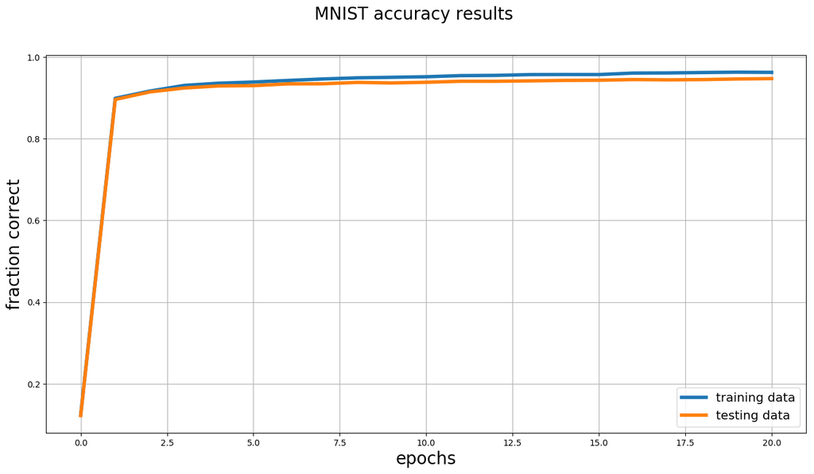

```
[0.124233 0.898767 0.916483 0.930367 0.935767 0.938617 0.94245 0.946067 0.9489 0.950167 0.95155 0.9543 0.954883 0.9568 0.957017 0.956933 0.960517 0.9608 0.961917 0.9627 0.962233; 0.1224 0.8959 0.9144 0.924 0.9291 0.9298 0.9341 0.9343 0.9377 0.9364 0.938 0.9405 0.9404 0.9414 0.9426 0.943 0.9447 0.944…
```

```julia
function test_mnist(NN::NeuralNetwork, X_test)
     X_test=convert_mnist(X_test)
     pred=predict_Y!(NN,X_test)
     return pred
end

Y_pred=test_mnist(NN_mnist,x_test)
# n, f =n_correct(Y_pred,y_test)
# println("The number of fraction of correctly predicted testing data is $f.")

fig=figure(figsize=(16,8))
subplot(111)

ax=gca()
suptitle("MNIST accuracy results", size=20)
ax[:plot](output.f_c[1,:], lw=4, label="training data")
ax[:plot](output.f_c[2,:], lw=4, label="testing data")
ax[:legend](loc="lower right", fontsize="x-large")
ax[:set_xlabel]("epochs", size=20)
ax[:set_ylabel]("fraction correct", size=20)
ax[:grid]()
println(output.f_c)
```

```julia
function plot_result(fin)

    start=fin-9
    fig=figure(figsize=(6,6))
    j=1
    for i in start:fin

        subplot(2,5,j)
        ax=gca()
        ax[:xaxis][:set_visible](false)
        ax[:yaxis][:set_visible](false)
        imshow(1-x_test[:,:,i]', cmap="gray")
        j+=1
    end
    tight_layout(w_pad=-1, h_pad=-17, pad=-0.5)
    p=Y_pred[start:fin]
    t=y_test[start:fin]
    println("The predicted values from left-right top-bottom are: $p.")
    println("The true values from left-right top-bottom are: $t.")
    n, _=n_correct(p,t)
    println("The total number correct is $n out of 10.")
    #savefig("mnist_example.png")
end
```

```
plot_result (generic function with 1 method)
```

Looking at the predictions for the testing data using the plot_result function.

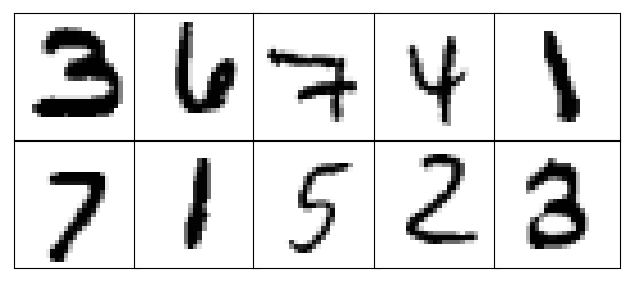

```
The predicted values from left-right top-bottom are: [3, 6, 7, 4, 1, 7, 1, 5, 2, 3].
The true values from left-right top-bottom are: [3, 6, 7, 4, 1, 7, 1, 5, 2, 3].
The total number correct is 10 out of 10.
```

```julia
plot_result(3130)
```

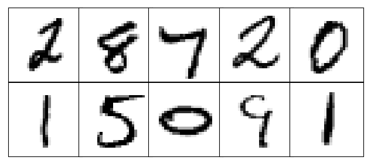

```
The predicted values from left-right top-bottom are: [2, 8, 7, 2, 0, 1, 5, 0, 4, 1].
The true values from left-right top-bottom are: [2, 8, 7, 2, 0, 1, 5, 0, 9, 1].
The total number correct is 9 out of 10.
```

```julia
plot_result(1194)
```

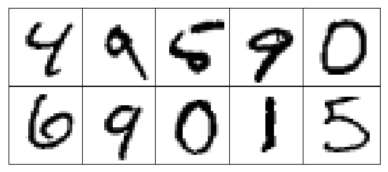

```
The predicted values from left-right top-bottom are: [4, 9, 6, 9, 0, 6, 9, 0, 1, 5].
The true values from left-right top-bottom are: [4, 9, 5, 9, 0, 6, 9, 0, 1, 5].
The total number correct is 9 out of 10.
```

```julia
plot_result(16)
```

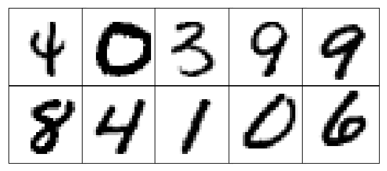

```
The predicted values from left-right top-bottom are: [4, 0, 3, 9, 9, 8, 4, 1, 0, 6].
The true values from left-right top-bottom are: [4, 0, 3, 9, 9, 8, 4, 1, 0, 6].
The total number correct is 10 out of 10.
```

```julia
plot_result(5008)
```

### Breast Cancer Data Analysis

The breast cancer data consists fo 30 features. Each of these need to be scaled. Scaling is done by the scale function that was imported from NeuralNetworkHelpers.jl. The neural network will consist of three layers, the final two being sigmoid, a learning rate of $\eta=0.1$, 100 epochs, and a mini-batch size of 20. Like the MNIST analysis accuracy is tracked for both the training and testing data.

```julia
# get cancer data
bc_data=readtable("breast_cancer.txt")
n=size(bc_data)
println("The size of the breast cancer data frame is $n")
```

```
The size of the breast cancer data frame is (568, 32)
```

```julia
X_train, Y_train, X_test, Y_test=train_test_split(bc_data[:,3:32],bc_data[:,2],.8);
X_train=scale_data(X_train); X_test=scale_data(X_test);
cls_bc=["M"; "B"]
network_struct=[30 nothing; 10 sigmoid_layer; 2 sigmoid_layer];
NN_bc=random_network(network_struct)


train_data_bc=NN_data{Float64}(X_train,Y_train, cls_bc)
test_data_bc=NN_data{Float64}(X_test,Y_test, cls_bc)

eta=0.1; mini_size=20; epochs=100
params_bc=Dict("epochs"=> epochs, "eta"=>eta, "mini size"=>mini_size)

@time output_bc=MBGD(NN_bc,train_data_bc,params_bc,test_data=test_data_bc);
#@time MBGD(NN_bc,train_data_bc,params_bc,track=false,test_data=test_data_bc);
```

```
  0.286592 seconds (511.29 k allocations: 47.493 MiB, 3.21% gc time)
```

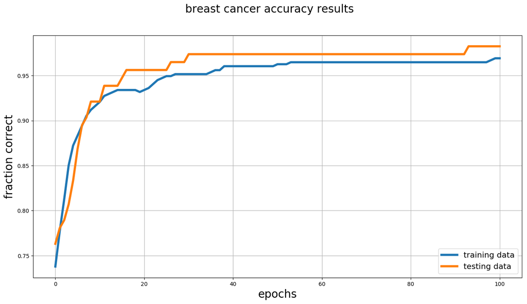

```julia
fig=figure(figsize=(16,8))
#, axes= subplots(1,2)
subplot(111)

ax=gca()
suptitle("breast cancer accuracy results", size=20)
ax[:plot](output_bc.f_c[1,:], lw=4, label="training data")
ax[:plot](output_bc.f_c[2,:],lw=4,  label="testing data")
ax[:legend](loc="lower right", fontsize="x-large")
ax[:set_xlabel]("epochs", size=20)
ax[:set_ylabel]("fraction correct", size=20)
ax[:grid]()
```